# Exploring Mental Health Data (Kaggle)

NBPub

Table of Contents

## Contents

- Overview
- Data Preparation
  - Unused Features
    - Name
    - CPGA
    - City
    - Profession
    - Degree
  - Ordinal Encoding and Cleaning
  - Coalesce Class Specific Features
  - Binary and One-Hot Encoding
- Data Exploration
  - Binary Features
  - Continuous Features
    - Collinearity
  - Ordinal Features
- *Final Preparation Steps*
  - Clean Columns
  - Missing Data
  - Summary Tables
- Modeling
  - Feature Importance
  - Evaluation and Metrics
- Model Comparison
  - Side-by-Side

## Overview

- Background
  - synthetic dataset provided by [Kaggle](https://www.kaggle.com/competitions/playground-series-s4e11/data), based on a previously published Depression [survey](https://www.kaggle.com/datasets/sumansharmadataworld/depression-surveydataset-for-analysis)
    - > comprehensive survey aimed at understanding the factors contributing to depression risk among adults . . . conducted across various cities, targeting individuals from diverse backgrounds and professions
  - the goal was to extract insights on everyday (non-clinical) factors that may correlate with mental health risks and to develop models for mental health prediction
- Purpose
  - **This notebook will exemplify data exploration, cleaning, and processing, and then ultimately train a simple logistic regression model for prediction of the target feature, `Depression`.**
  - details and justifications are provided in each section
    - The aim of this notebook is not to develop a performant model, but I may update this section with competition submission results and briefly describe approaches taken outside of this notebook.
- R Libraries, document created with **[R Markdown](https://rmarkdown.rstudio.com/)**
  - **[dplyr](https://dplyr.tidyverse.org/)**, data processing
  - **[gtsummary](https://www.danieldsjoberg.com/gtsummary/)**, tables and statistics
    - also used **[knitr](https://yihui.org/knitr/)**
  - **[ggplot2](https://ggplot2.tidyverse.org/)**, graphing
  - **[parsnip](https://parsnip.tidymodels.org/)**, unified model interface for logistic regression models, utilizing the following engines
    - [glmnet](https://glmnet.stanford.edu/)
    - glm
  - **[yardstick](https://yardstick.tidymodels.org/)**, model metrics

```r
library(tidyverse)
library(tidymodels)
library(gtsummary)
library(glmnet)
data <- read_csv("datasets/playground-series-s4e11_train.csv")
# remove spaces and special characters in features for plotting and indexing
names(data) <- gsub(" ", "_", names(data))
names(data) <- gsub("\\?", "", names(data))
names(data) <- gsub("/", "_", names(data))

glimpse(data[1:8,])
```

```
Rows: 8
Columns: 20
$ id                                   <dbl> 0, 1, 2, 3, 4, 5, 6, 7
$ Name                                 <chr> "Aaradhya", "Vivan", "Yuvraj", "Yuvraj", "Rhea", "Vani", "Ritvik", "Rajveer"
$ Gender                               <chr> "Female", "Male", "Male", "Male", "Female", "Female", "Male", "Male"
$ Age                                  <dbl> 49, 26, 33, 22, 30, 59, 47, 38
$ City                                 <chr> "Ludhiana", "Varanasi", "Visakhapatnam", "Mumbai", "Kanpur", "Ahmedabad", "Than…
$ Working_Professional_or_Student      <chr> "Working Professional", "Working Professional", "Student", "Working Professiona…
$ Profession                           <chr> "Chef", "Teacher", NA, "Teacher", "Business Analyst", "Finanancial Analyst", "C…
$ Academic_Pressure                    <dbl> NA, NA, 5, NA, NA, NA, NA, NA
$ Work_Pressure                        <dbl> 5, 4, NA, 5, 1, 2, 5, 3
$ CGPA                                 <dbl> NA, NA, 8.97, NA, NA, NA, NA, NA
$ Study_Satisfaction                   <dbl> NA, NA, 2, NA, NA, NA, NA, NA
$ Job_Satisfaction                     <dbl> 2, 3, NA, 1, 1, 5, 2, 4
$ Sleep_Duration                       <chr> "More than 8 hours", "Less than 5 hours", "5-6 hours", "Less than 5 hours", "5-…
$ Dietary_Habits                       <chr> "Healthy", "Unhealthy", "Healthy", "Moderate", "Unhealthy", "Healthy", "Moderat…
$ Degree                               <chr> "BHM", "LLB", "B.Pharm", "BBA", "BBA", "MCA", "MD", "B.Pharm"
$ Have_you_ever_had_suicidal_thoughts_ <chr> "No", "Yes", "Yes", "Yes", "Yes", "No", "No", "No"
$ Work_Study_Hours                     <dbl> 1, 7, 3, 10, 9, 7, 6, 10
$ Financial_Stress                     <dbl> 2, 3, 1, 1, 4, 5, 2, 3
$ Family_History_of_Mental_Illness     <chr> "No", "No", "No", "Yes", "Yes", "No", "No", "Yes"
$ Depression                           <dbl> 0, 1, 1, 1, 0, 0, 0, 0
```

## Data Preparation

- cleaning, encoding, and dropping features
  - preparing data for simplest model engines, make all features numerical

### Unused Features to be Dropped

- *will do brief exploration and analysis here*
  - features would likely improve model predictions, but will still consider these outside of the scope of this notebook and modeling effort
- **id, Name**
  - shouldn’t have relationship to target, id is simply an index
  - could theoretically extract dialect / cultural information from names
- **CGPA**
  - student specific (most rows missing data as survey is ~20% students)
    - see binary feature exploration
  - weak relationship to target, depression rates steady across CGPA range
    - may be more useful if considered in conjunction with `Degree`
- **City, Profession, Degree**
  - most respondents within top 30-40 common responses, but decent amount occupy less common or completely unique categories
  - extensive cleaning required for `Profession` and `Degree`
  - too many values to simply encode

#### Name

```r
count(data, Name, sort = TRUE)
```

| Name | n |
| --- | --- |
| Rohan | 3178 |
| Aarav | 2336 |
| Rupak | 2176 |
| Aaradhya | 2045 |
| Anvi | 2035 |
| Raghavendra | 1877 |
| Vani | 1657 |
| Tushar | 1596 |
| Ritvik | 1589 |
| Shiv | 1568 |

[output cut: 412 more lines]

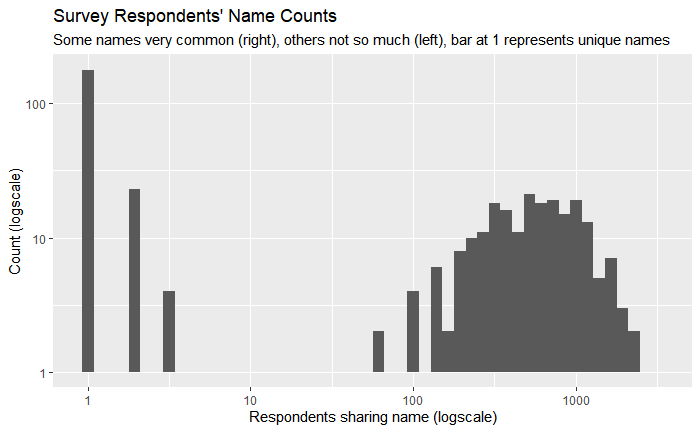

#### CGPA

| **Characteristic** | **0** N = 115,133<sup>1</sup> | **1** N = 25,567<sup>1</sup> |
| --- | --- | --- |
| CGPA | 7.64 (6.25, 8.93) | 7.85 (6.37, 8.91) |
| Unknown | 103,571 | 9,231 |

<sup>1</sup> Median (Q1, Q3)

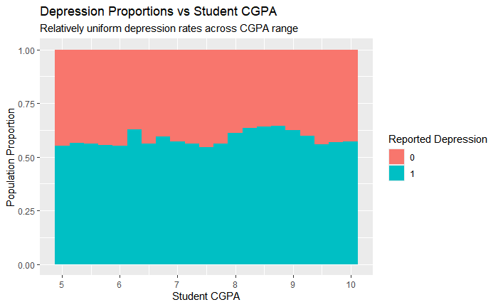

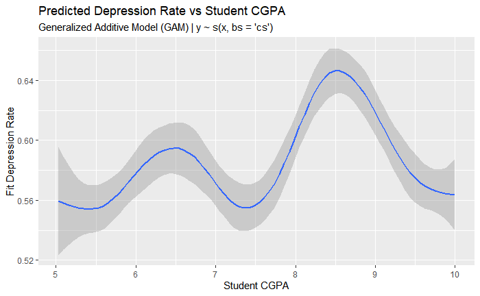

#### City

- city counts and depression rates of most common **cities** (table below), recall overall rate is `18%`
  - Hyderabad and Thane stand out on the high end
  - Meerut and Mumbai on the low end

```r
count(data, City, sort = TRUE)
```

| City | n |
| --- | --- |
| Kalyan | 6591 |
| Patna | 5924 |
| Vasai-Virar | 5765 |
| Kolkata | 5689 |
| Ahmedabad | 5613 |
| Meerut | 5528 |
| Ludhiana | 5226 |
| Pune | 5210 |
| Rajkot | 5207 |
| Visakhapatnam | 5176 |

[output cut: 88 more lines]

```r
cities <- count(data, City, sort = TRUE) %>% filter(n>3000) %>% select(City)
data_city <- data %>% filter(City %in% cities$City)
tbl_summary(data_city, by=Depression, include=City, percent="row")
```

| **Characteristic** | **0** N = 115,054<sup>1</sup> | **1** N = 25,548<sup>1</sup> |
| --- | --- | --- |
| City |  |  |
| Agra | 3,783 (81%) | 901 (19%) |
| Ahmedabad | 4,390 (78%) | 1,223 (22%) |
| Bangalore | 3,399 (82%) | 724 (18%) |
| Bhopal | 2,667 (77%) | 808 (23%) |
| Chennai | 3,258 (81%) | 786 (19%) |
| Delhi | 2,904 (81%) | 689 (19%) |
| Faridabad | 2,788 (85%) | 480 (15%) |
| Ghaziabad | 2,914 (80%) | 706 (20%) |
| Hyderabad | 3,259 (72%) | 1,237 (28%) |
| Indore | 4,088 (84%) | 784 (16%) |
| Jaipur | 3,543 (82%) | 785 (18%) |
| Kalyan | 5,275 (80%) | 1,316 (20%) |
| Kanpur | 3,845 (87%) | 553 (13%) |
| Kolkata | 4,701 (83%) | 988 (17%) |
| Lucknow | 3,364 (79%) | 916 (21%) |
| Ludhiana | 4,219 (81%) | 1,007 (19%) |
| Meerut | 4,787 (87%) | 741 (13%) |
| Mumbai | 4,314 (87%) | 652 (13%) |
| Nagpur | 3,599 (86%) | 610 (14%) |
| Nashik | 2,645 (84%) | 499 (16%) |
| Patna | 4,957 (84%) | 967 (16%) |
| Pune | 4,371 (84%) | 839 (16%) |
| Rajkot | 4,305 (83%) | 902 (17%) |
| Srinagar | 4,000 (79%) | 1,074 (21%) |
| Surat | 3,700 (80%) | 936 (20%) |
| Thane | 3,250 (76%) | 1,039 (24%) |
| Vadodara | 3,802 (83%) | 766 (17%) |
| Varanasi | 3,951 (86%) | 655 (14%) |
| Vasai-Virar | 4,624 (80%) | 1,141 (20%) |
| Visakhapatnam | 4,352 (84%) | 824 (16%) |

<sup>1</sup> n (%)

#### Profession

- profession counts and depression rates of most common professions (table below), recall overall rate is `18%`
  - all of the most common professions have lower depression rates than the overall survey population
  - “Unknown” likely corresponds mostly to students, who have a relatively high rate of depression

```r
count(data, Profession, sort = TRUE)
```

| Profession | n |
| --- | --- |
| NA | 36630 |
| Teacher | 24906 |
| Content Writer | 7814 |
| Architect | 4370 |
| Consultant | 4229 |
| HR Manager | 4022 |
| Pharmacist | 3893 |
| Doctor | 3255 |
| Business Analyst | 3161 |
| Entrepreneur | 2968 |

[output cut: 55 more lines]

```r
profs <- count(data, Profession, sort = TRUE) %>% filter(n>2000) %>% select(Profession)
data_profs <- data %>% filter(Profession %in% profs$Profession)
tbl_summary(data_profs, by=Depression, include=Profession, percent="row")
```

| **Characteristic** | **0** N = 89,233<sup>1</sup> | **1** N = 23,681<sup>1</sup> |
| --- | --- | --- |
| Profession |  |  |
| Architect | 3,937 (90%) | 433 (9.9%) |
| Business Analyst | 2,982 (94%) | 179 (5.7%) |
| Chef | 2,723 (95%) | 139 (4.9%) |
| Chemist | 2,883 (97%) | 84 (2.8%) |
| Consultant | 4,030 (95%) | 199 (4.7%) |
| Content Writer | 7,668 (98%) | 146 (1.9%) |
| Customer Support | 1,962 (95%) | 93 (4.5%) |
| Data Scientist | 2,204 (92%) | 186 (7.8%) |
| Doctor | 3,083 (95%) | 172 (5.3%) |
| Educational Consultant | 2,639 (93%) | 213 (7.5%) |
| Entrepreneur | 2,906 (98%) | 62 (2.1%) |
| HR Manager | 3,592 (89%) | 430 (11%) |
| Lawyer | 2,046 (92%) | 166 (7.5%) |
| Pharmacist | 3,789 (97%) | 104 (2.7%) |
| Researcher | 2,234 (96%) | 94 (4.0%) |
| Teacher | 23,520 (94%) | 1,386 (5.6%) |
| Unknown | 17,035 | 19,595 |

<sup>1</sup> n (%)

#### Degree

- degree counts and depression rates of most common degrees (second table), recall overall rate is `18%`
- initial look indicates varied rates between degrees, but each degree was considered for current students and professionals separately (third table)
  - students base depression rate is ~59% and working professionals are ~8%
  - this important confounding feature will be discussed further in the Collinearity section
  - “Class 12” (assuming this is a American high school / GED equivalent) has highest depression rates for current students and professionals by a wide margin
  - “M. Ed” has relatively low depression rates for students and professionals

```r
count(data, Degree, sort = TRUE)
```

| Degree | n |
| --- | --- |
| Class 12 | 14729 |
| B.Ed | 11691 |
| B.Arch | 8742 |
| B.Com | 8113 |
| B.Pharm | 5856 |
| BCA | 5739 |
| M.Ed | 5668 |
| MCA | 5234 |
| BBA | 5030 |
| BSc | 5027 |

[output cut: 106 more lines]

```r
degs <- count(data, Degree, sort = TRUE) %>% filter(n>4000) %>% select(Degree)
data_degs <- data %>% filter(Degree %in% degs$Degree)
tbl_summary(data_degs, by=Depression, include=Degree, percent="row")
```

| **Characteristic** | **0** N = 86,290<sup>1</sup> | **1** N = 21,155<sup>1</sup> |
| --- | --- | --- |
| Degree |  |  |
| B.Arch | 7,365 (84%) | 1,377 (16%) |
| B.Com | 6,850 (84%) | 1,263 (16%) |
| B.Ed | 10,186 (87%) | 1,505 (13%) |
| B.Pharm | 5,158 (88%) | 698 (12%) |
| B.Tech | 3,478 (79%) | 947 (21%) |
| BBA | 4,354 (87%) | 676 (13%) |
| BCA | 4,569 (80%) | 1,170 (20%) |
| BHM | 3,562 (83%) | 743 (17%) |
| BSc | 4,245 (84%) | 782 (16%) |
| Class 12 | 7,180 (49%) | 7,549 (51%) |
| LLB | 3,693 (85%) | 655 (15%) |
| LLM | 4,117 (89%) | 530 (11%) |
| M.Ed | 5,117 (90%) | 551 (9.7%) |
| M.Pharm | 4,092 (90%) | 445 (9.8%) |
| M.Tech | 3,828 (86%) | 647 (14%) |
| MCA | 4,466 (85%) | 768 (15%) |
| MSc | 4,030 (83%) | 849 (17%) |

<sup>1</sup> n (%)

```r
tbl_strata(data_degs %>% select(Degree, Working_Professional_or_Student, Depression),
           strata=Working_Professional_or_Student,
           .tbl_fun = ~.x |> tbl_summary(by=Depression, percent="row"))
```

| **Characteristic** | **Student** **0** N = 9,155<sup>1</sup> | **Student** **1** N = 13,492<sup>1</sup> | **Working Professional** **0** N = 77,135<sup>1</sup> | **Working Professional** **1** N = 7,663<sup>1</sup> |
| --- | --- | --- | --- | --- |
| Degree |  |  |  |  |
| B.Arch | 607 (41%) | 871 (59%) | 6,758 (93%) | 506 (7.0%) |
| B.Com | 653 (43%) | 853 (57%) | 6,197 (94%) | 410 (6.2%) |
| B.Ed | 846 (45%) | 1,021 (55%) | 9,340 (95%) | 484 (4.9%) |
| B.Pharm | 382 (47%) | 428 (53%) | 4,776 (95%) | 270 (5.4%) |
| B.Tech | 497 (43%) | 655 (57%) | 2,981 (91%) | 292 (8.9%) |
| BBA | 289 (42%) | 407 (58%) | 4,065 (94%) | 269 (6.2%) |
| BCA | 614 (43%) | 819 (57%) | 3,955 (92%) | 351 (8.2%) |
| BHM | 416 (45%) | 509 (55%) | 3,146 (93%) | 234 (6.9%) |
| BSc | 365 (41%) | 523 (59%) | 3,880 (94%) | 259 (6.3%) |
| Class 12 | 1,777 (29%) | 4,303 (71%) | 5,403 (62%) | 3,246 (38%) |
| LLB | 315 (47%) | 356 (53%) | 3,378 (92%) | 299 (8.1%) |
| LLM | 223 (46%) | 259 (54%) | 3,894 (93%) | 271 (6.5%) |
| M.Ed | 406 (49%) | 415 (51%) | 4,711 (97%) | 136 (2.8%) |
| M.Pharm | 268 (46%) | 314 (54%) | 3,824 (97%) | 131 (3.3%) |
| M.Tech | 501 (49%) | 521 (51%) | 3,327 (96%) | 126 (3.6%) |
| MCA | 485 (46%) | 559 (54%) | 3,981 (95%) | 209 (5.0%) |
| MSc | 511 (43%) | 679 (57%) | 3,519 (95%) | 170 (4.6%) |

<sup>1</sup> n (%)

### Clean and Encode (Ordinal Features)

#### Sleep_Duration

- categories: <5, 5-6, 7-8, >8 hours | *will encode with values 1-4, respectively*
  - some values obviously fit within categories and will be changed
    - made some arbitrary choices, like “4-6 hours” and “1-6 hours”
  - bogus and unclear values were dropped

```r
dplyr::count(data, Sleep_Duration, sort = TRUE)
```

| Sleep_Duration | n |
| --- | --- |
| Less than 5 hours | 38784 |
| 7-8 hours | 36969 |
| More than 8 hours | 32726 |
| 5-6 hours | 32142 |
| 3-4 hours | 12 |
| 6-7 hours | 8 |
| 4-5 hours | 7 |
| 2-3 hours | 5 |
| 4-6 hours | 5 |
| 1-6 hours | 4 |

[output cut: 26 more lines]

```r
# encode sleep, first value in array indicates overall grouping

data <- data %>% mutate(Sleep_Rank = case_match(pull(data,Sleep_Duration),
  c("Less than 5 hours", "3-4 hours", "4-5 hours", "2-3 hours", "1-6 hours",
    "45", "1-2 hours", "1-3 hours", "3-6 hours") ~ 1,
  c("5-6 hours", "4-6 hours", "6-7 hours") ~ 2,
  c("7-8 hours", "6-8 hours", "8 hours") ~ 3,
  c("More than 8 hours", "10-11 hours", "8-9 hours", "9-11 hours") ~ 4
))

paste(sum(is.na(data["Sleep_Rank"])), "sleep values missing after encoding")
```

```
[1] "22 sleep values missing after encoding"
```

#### Dietary_Habits

- categories: Unhealthy, Moderate, Healthy | *will encode with values 1-3*
  - very small proportion of data outside these answers and were dropped, though some could be inferred
    - ex: are “No” or “No Healthy” equivalent to “Unhealthy”?

```r
dplyr::count(data, Dietary_Habits, sort = TRUE)
```

| Dietary_Habits | n |
| --- | --- |
| Moderate | 49705 |
| Unhealthy | 46227 |
| Healthy | 44741 |
| NA | 4 |
| More Healthy | 2 |
| No | 2 |
| Yes | 2 |
| 1.0 | 1 |
| 2 | 1 |
| 3 | 1 |

[output cut: 14 more lines]

```r
data <- data %>% mutate(Diet_Rank = case_match(pull(data,Dietary_Habits),
  c("Unhealthy") ~ 1,
  c("Moderate") ~ 2,
  c("Healthy") ~ 3,
))

paste(sum(is.na(data["Diet_Rank"])), "diet values missing after encoding")
```

```
[1] "27 diet values missing after encoding"
```

### Combine Class-Specific Features

- Common features specific to Students or Working Professionals, these correspond to the majority of missing survey data
  - Academic or Work Pressure –> `Pressure`
  - Study or Job Satisfaction –> `Satisfaction`

```r
data <- data %>% mutate(Pressure = coalesce(Academic_Pressure, Work_Pressure))
data <- data %>% mutate(Satisfaction = coalesce(Study_Satisfaction, Job_Satisfaction))

head(data[c("Working_Professional_or_Student", "Academic_Pressure",
            "Work_Pressure", "Pressure")])
```

| Working_Professional_or_Student | Academic_Pressure | Work_Pressure | Pressure |
| --- | --- | --- | --- |
| Working Professional | NA | 5 | 5 |
| Working Professional | NA | 4 | 4 |
| Student | 5 | NA | 5 |
| Working Professional | NA | 5 | 5 |
| Working Professional | NA | 1 | 1 |
| Working Professional | NA | 2 | 2 |

```r
head(data[c("Working_Professional_or_Student", "Study_Satisfaction",
            "Job_Satisfaction", "Satisfaction")])
```

| Working_Professional_or_Student | Study_Satisfaction | Job_Satisfaction | Satisfaction |
| --- | --- | --- | --- |
| Working Professional | NA | 2 | 2 |
| Working Professional | NA | 3 | 3 |
| Student | 2 | NA | 2 |
| Working Professional | NA | 1 | 1 |
| Working Professional | NA | 1 | 1 |
| Working Professional | NA | 5 | 5 |

### Encode Binary Responses

- `Gender`, `Have_you_ever_had_suicidal_thoughts_`, `Family_History_of_Mental_Illness`, and `Working_Professional_or_Student`
  - *survey only contains two responses to gender, not enforcing a binary*
- Could have used binary encoding for gender and student vs working professional, but chose to use **one-hot encoding** to see how models handled features

```r
# one hot encode
data <- data %>% mutate(Gender_M = ifelse(Gender=="Male",1,0))
data <- data %>% mutate(Gender_F = ifelse(Gender=="Female",1,0))

data <- data %>% mutate(Professional = ifelse(Working_Professional_or_Student==
                                                "Working Professional",1,0))
data <- data %>% mutate(Student = ifelse(Working_Professional_or_Student==
                                                "Student",1,0))

# binary encode, character to numerical
data <- data %>% mutate(Suicidal_Thoughts = ifelse(
  Have_you_ever_had_suicidal_thoughts_=="Yes",1,0))

data <- data %>% mutate(Family_History = ifelse(
  Family_History_of_Mental_Illness=="Yes",1,0))
```

## Exploration Tables and Graphs

- feature distributions, target relationships, and interrelationships
- *`Depression = 1` corresponds to `"yes"` and `0` to `"no"`*

### Binary Features

- response counts
  - binary feature responses are balanced, except for students vs working professionals and target feature, `Depression`
- relationship to Depression
  - having suicidal thoughts and being a student are tied much more strongly to reported depression than the alternatives (not having suicidal thoughts, being a working professional)
  - gender and family history of mental illness do not strongly influence target
  - *table presented against Depression in final summary*

| **Characteristic** | **N = 140,700**<sup>1</sup> |
| --- | --- |
| Gender |  |
| Female | 63,236 (45%) |
| Male | 77,464 (55%) |
| Have_you_ever_had_suicidal_thoughts_ | 69,562 (49%) |
| Family_History_of_Mental_Illness | 69,942 (50%) |
| Working_Professional_or_Student |  |
| Student | 27,901 (20%) |
| Working Professional | 112,799 (80%) |
| Depression | 25,567 (18%) |

<sup>1</sup> n (%)

**Gender**

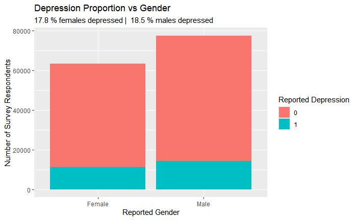

**Suicidal Thoughts**

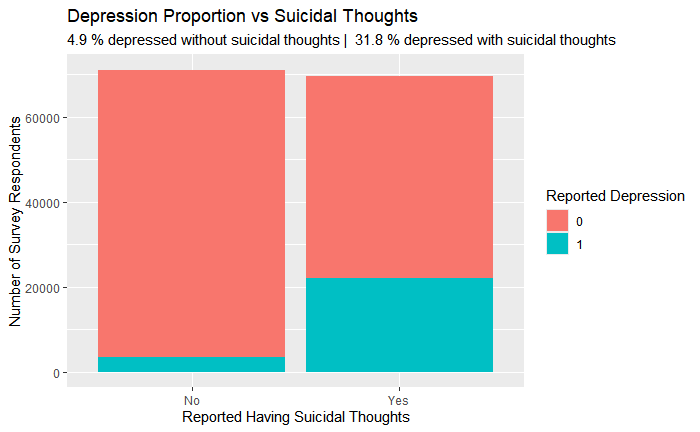

**Family History of Mental Illness**

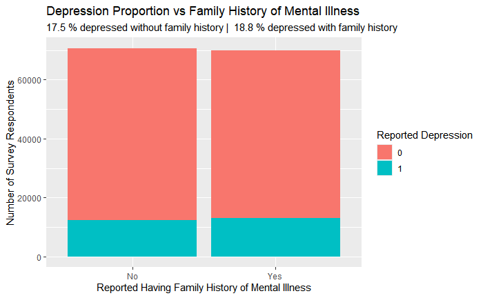

**Student or Working Professional**

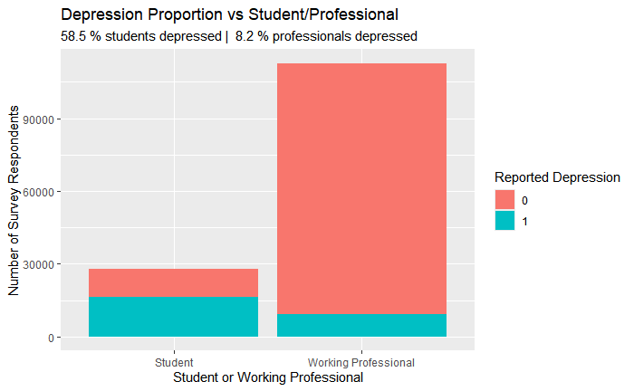

### Continuous Features

- higher work-study hours and lower ages match up with much higher rates of reported depression
  - *table shows each feature against Depression: 0 (no) or 1 (yes)*
- however each feature is entangled with the student/working professional classification of survey respondents

```r
tbl_summary(data, by=Depression,
            include=c("Age", "Work_Study_Hours",))
```

| **Characteristic** | **0** N = 115,133<sup>1</sup> | **1** N = 25,567<sup>1</sup> |
| --- | --- | --- |
| Age | 45 (37, 53) | 24 (20, 29) |
| Work_Study_Hours | 6.0 (2.0, 9.0) | 9.0 (6.0, 11.0) |

<sup>1</sup> Median (Q1, Q3)

**Work or Study Hours**

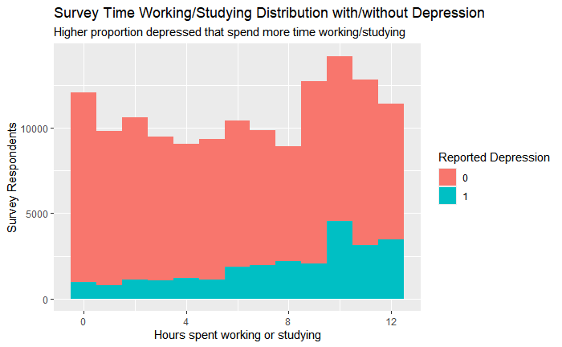

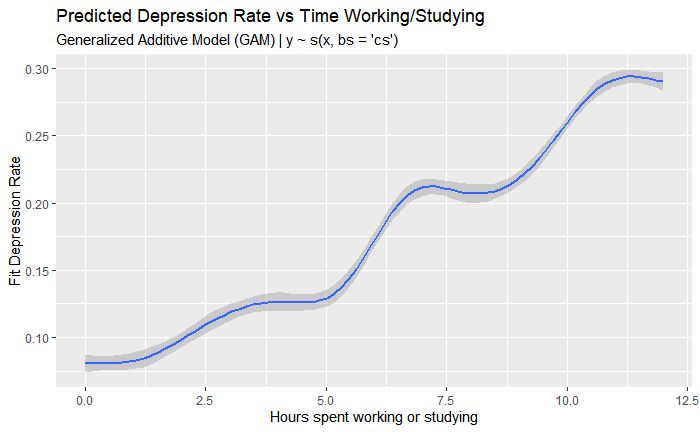

**Age**

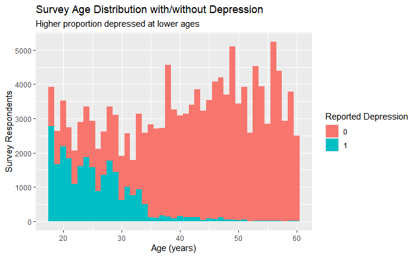

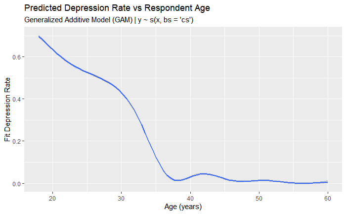

#### Relationship with Student - Working Professional

```r
tbl_strata(data %>% select(Age, Work_Study_Hours,
                           Working_Professional_or_Student, Depression),
           strata=Working_Professional_or_Student,
           .tbl_fun = ~.x |> tbl_summary(by=Depression,
                                         statistic = all_continuous() ~
                                           "{mean} | {median} ({p25}, {p75})"))
```

| **Characteristic** | **Student** **0** N = 11,565<sup>1</sup> | **Student** **1** N = 16,336<sup>1</sup> | **Working Professional** **0** N = 103,568<sup>1</sup> | **Working Professional** **1** N = 9,231<sup>1</sup> |
| --- | --- | --- | --- | --- |
| Age | 27.1 \| 28.0 (23.0, 31.0) | 24.9 \| 24.0 (21.0, 28.0) | 46 \| 47 (39, 53) | 27 \| 24 (20, 31) |
| Work_Study_Hours | 6.2 \| 6.0 (3.0, 10.0) | 7.8 \| 9.0 (6.0, 11.0) | 5.9 \| 6.0 (2.0, 9.0) | 7.8 \| 9.0 (6.0, 11.0) |

<sup>1</sup> Mean | Median (Q1, Q3)

**Age**

| **Characteristic** | **N = 140,700**<sup>1</sup> |
| --- | --- |
| Working_Professional_or_Student |  |
| Student | 25 (21, 30) |
| Working Professional | 46 (38, 53) |
| Depression |  |
| 0 | 45 (37, 53) |
| 1 | 24 (20, 29) |

<sup>1</sup> Age: Median (Q1, Q3)

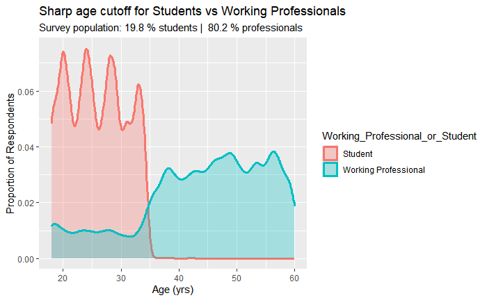

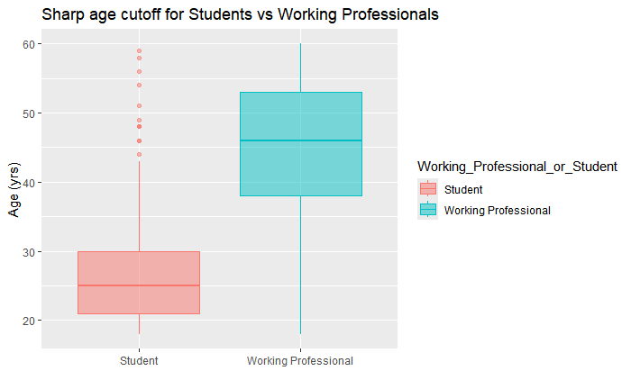

**Work-Study Hours**

| **Characteristic** | **N = 140,700**<sup>1</sup> |
| --- | --- |
| Working_Professional_or_Student |  |
| Student | 8.0 (4.0, 10.0) |
| Working Professional | 6.0 (3.0, 9.0) |
| Depression |  |
| 0 | 6.0 (2.0, 9.0) |
| 1 | 9.0 (6.0, 11.0) |

<sup>1</sup> Work_Study_Hours: Median (Q1, Q3)

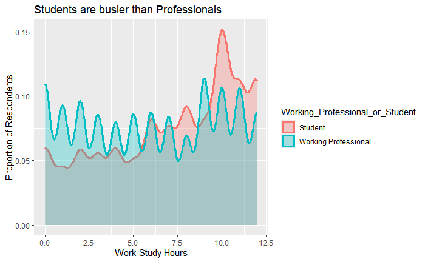

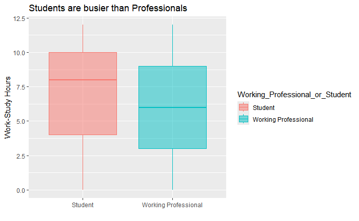

### Ordinal Features

- table shows separate student or working professional specific **Pressure** and **Satisfaction** to show different rates between students and working professionals
  - overall `Pressure` and `Satisfaction` against `Depression` is shown in the graphs below and in the final tables
- generally low slope magnitudes and R2’s indicate features don’t strongly influence target alone. sign of slope (+/-) helpful indication of relationships
  - overall feature ranges should be considered when comparing slopes
  - *could subtract `1` to get more meaningful intercept values*
- `Financial_Stress` and `Pressure` show strongest relationships to `Depression`
- should expect self-reported, subjective features to be less useful than continuous variables.
  - lower granularity of ranked features is probably good for survey design, but may limit extractable target relationships

```r
tbl_summary(data, by=Depression,
            include=c("Academic_Pressure", "Work_Pressure",
                         "Study_Satisfaction", "Job_Satisfaction",
                         "Financial_Stress", "Sleep_Rank", "Diet_Rank"),
            percent="cell")
```

| **Characteristic** | **0** N = 115,133<sup>1</sup> | **1** N = 25,567<sup>1</sup> |
| --- | --- | --- |
| Academic_Pressure |  |  |
| 1 | 3,869 (14%) | 932 (3.3%) |
| 2 | 2,612 (9.4%) | 1,567 (5.6%) |
| 3 | 2,973 (11%) | 4,490 (16%) |
| 4 | 1,231 (4.4%) | 3,927 (14%) |
| 5 | 876 (3.1%) | 5,420 (19%) |
| Unknown | 103,572 | 9,231 |
| Work_Pressure |  |  |
| 1 | 21,077 (19%) | 485 (0.4%) |
| 2 | 23,586 (21%) | 787 (0.7%) |
| 3 | 20,708 (18%) | 1,191 (1.1%) |
| 4 | 20,153 (18%) | 2,359 (2.1%) |
| 5 | 18,036 (16%) | 4,400 (3.9%) |
| Unknown | 11,573 | 16,345 |
| Study_Satisfaction |  |  |
| 1 | 1,594 (5.7%) | 3,857 (14%) |
| 2 | 2,071 (7.4%) | 3,769 (14%) |
| 3 | 2,469 (8.9%) | 3,354 (12%) |
| 4 | 3,095 (11%) | 3,265 (12%) |
| 5 | 2,334 (8.4%) | 2,089 (7.5%) |
| Unknown | 103,570 | 9,233 |
| Job_Satisfaction |  |  |
| 1 | 18,439 (16%) | 3,885 (3.4%) |
| 2 | 22,346 (20%) | 2,437 (2.2%) |
| 3 | 20,755 (18%) | 1,196 (1.1%) |
| 4 | 20,095 (18%) | 825 (0.7%) |
| 5 | 21,928 (19%) | 884 (0.8%) |
| Unknown | 11,570 | 16,340 |
| Financial_Stress |  |  |
| 1 | 24,899 (18%) | 2,312 (1.6%) |
| 2 | 28,261 (20%) | 3,190 (2.3%) |
| 3 | 21,463 (15%) | 4,527 (3.2%) |
| 4 | 21,651 (15%) | 6,114 (4.3%) |
| 5 | 18,856 (13%) | 9,423 (6.7%) |
| Unknown | 3 | 1 |
| Sleep_Rank |  |  |
| 1 | 29,713 (21%) | 9,104 (6.5%) |
| 2 | 26,830 (19%) | 5,325 (3.8%) |
| 3 | 30,380 (22%) | 6,594 (4.7%) |
| 4 | 28,190 (20%) | 4,542 (3.2%) |
| Unknown | 20 | 2 |
| Diet_Rank |  |  |
| 1 | 34,183 (24%) | 12,044 (8.6%) |
| 2 | 41,472 (29%) | 8,233 (5.9%) |
| 3 | 39,460 (28%) | 5,281 (3.8%) |
| Unknown | 18 | 9 |

<sup>1</sup> n (%)

**Sleep**

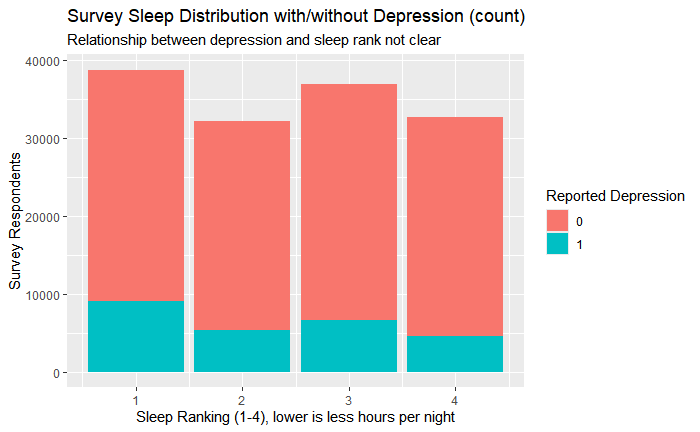

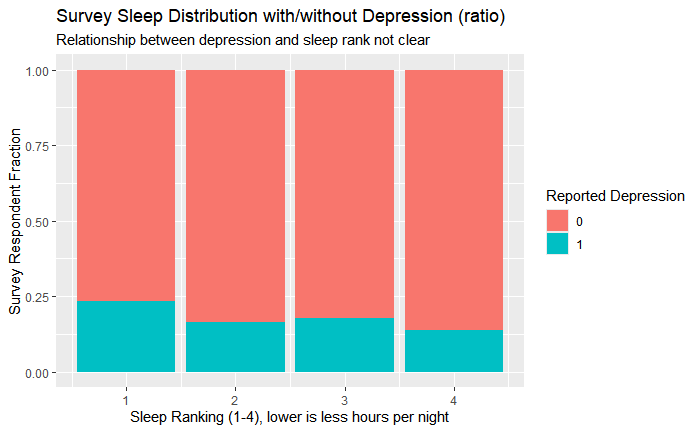

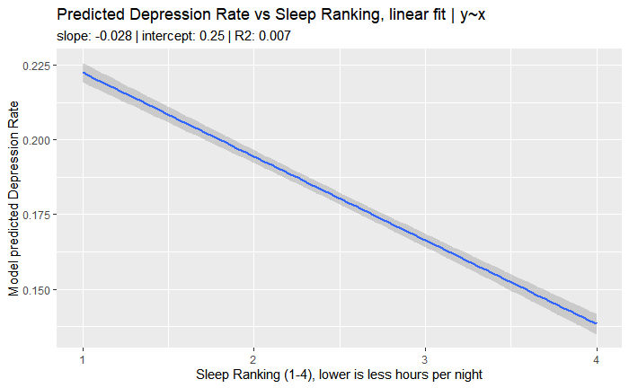

**Diet**

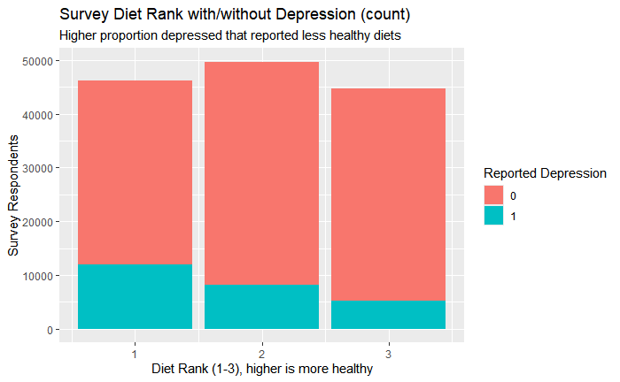

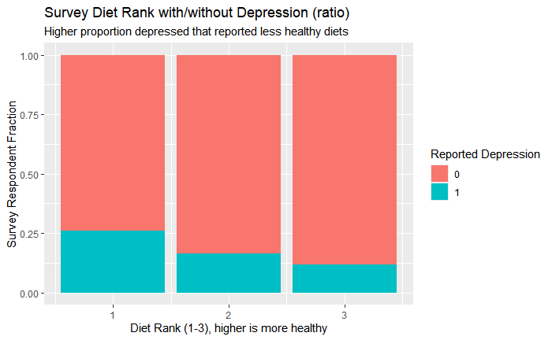

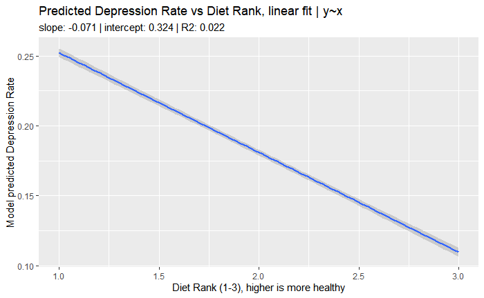

**Satisfaction (Job, Studies)**

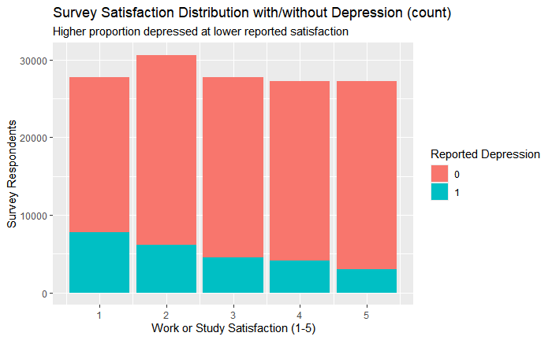

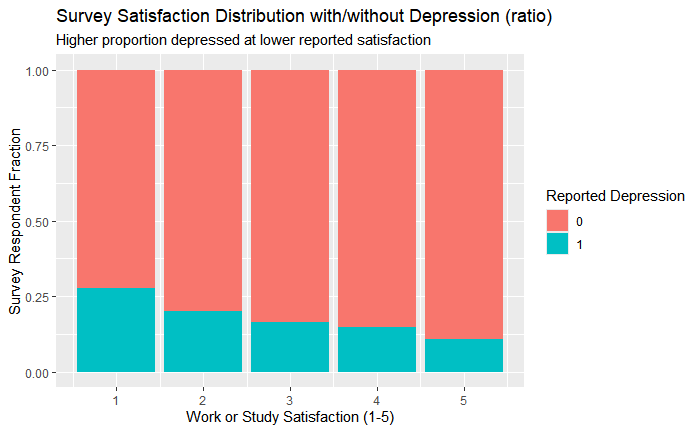

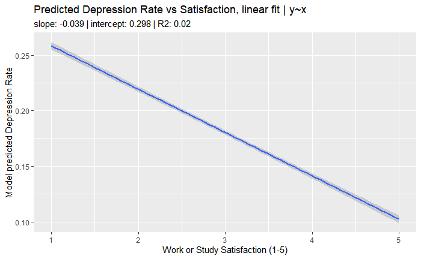

**Pressure (Work, Studies)**

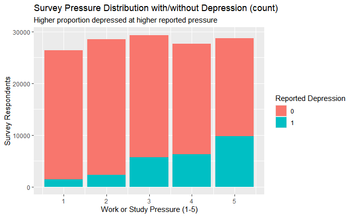

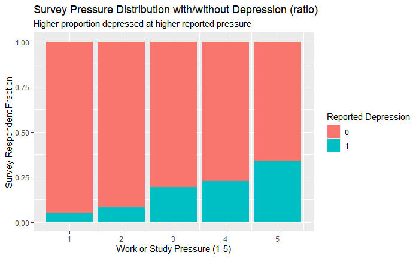

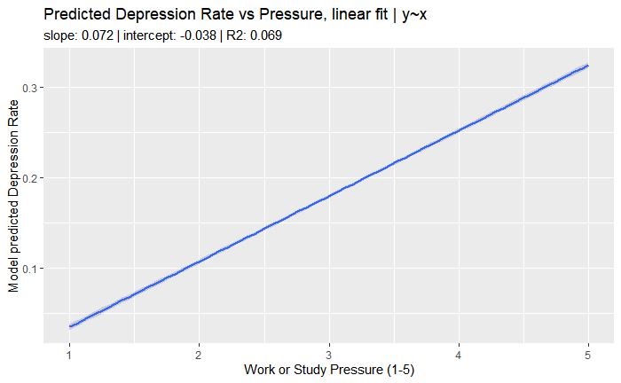

**Financial Stress**

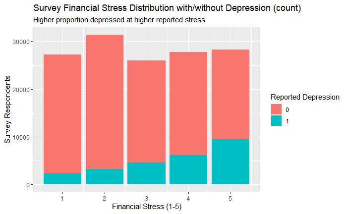

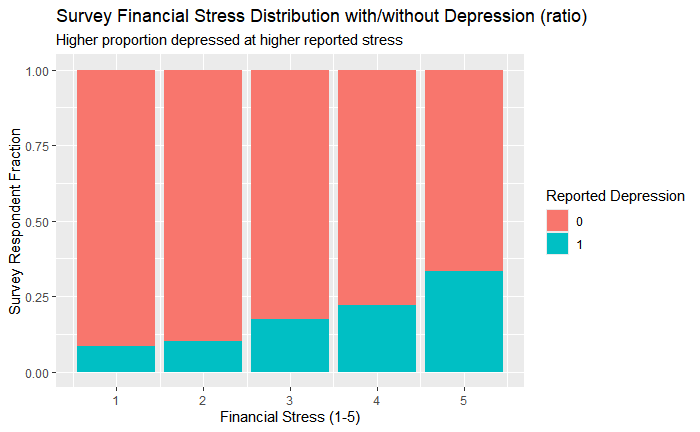

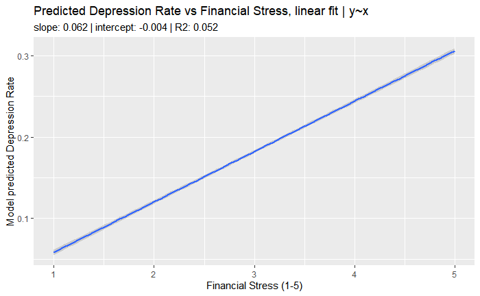

### Drop Columns

- drop processed and unused features
- remaining features are now numeric for model

```r
# drop features not used for model
# id, profession, cgpa, name, city, degree
keep_cols <- c(
  "Gender_M", "Gender_F", "Age", "Professional", "Student",
  "Suicidal_Thoughts",  "Family_History", "Work_Study_Hours",
  "Financial_Stress", "Pressure", "Satisfaction", "Sleep_Rank", "Diet_Rank",
  "Depression"
)

data <- data[,keep_cols]
glimpse(data[1:10,keep_cols])
```

```
Rows: 10
Columns: 14
$ Gender_M          <dbl> 0, 1, 1, 1, 0, 0, 1, 1, 0, 0
$ Gender_F          <dbl> 1, 0, 0, 0, 1, 1, 0, 0, 1, 1
$ Age               <dbl> 49, 26, 33, 22, 30, 59, 47, 38, 24, 42
$ Professional      <dbl> 1, 1, 0, 1, 1, 1, 1, 1, 0, 1
$ Student           <dbl> 0, 0, 1, 0, 0, 0, 0, 0, 1, 0
$ Suicidal_Thoughts <dbl> 0, 1, 1, 1, 1, 0, 0, 0, 0, 1
$ Family_History    <dbl> 0, 0, 0, 1, 1, 0, 0, 1, 1, 1
$ Work_Study_Hours  <dbl> 1, 7, 3, 10, 9, 7, 6, 10, 3, 7
$ Financial_Stress  <dbl> 2, 3, 1, 1, 4, 5, 2, 3, 2, 2
$ Pressure          <dbl> 5, 4, 5, 5, 1, 2, 5, 3, 2, 4
$ Satisfaction      <dbl> 2, 3, 2, 1, 1, 5, 2, 4, 5, 1
$ Sleep_Rank        <dbl> 4, 1, 2, 1, 2, 2, 3, 3, 2, 2
$ Diet_Rank         <dbl> 3, 1, 3, 2, 1, 3, 2, 1, 2, 3
$ Depression        <dbl> 0, 1, 1, 1, 0, 0, 0, 0, 0, 0
```

### Missing Values

```r
missing <- data %>% filter(if_any(everything(), is.na))

print(paste(
  dim(missing)[1], "responses with missing data out of", dim(data)[1])
  )
```

```
[1] "82 responses with missing data out of 140700"
```

```r
options(knitr.kable.NA=
          "<span style='background-color:red;'>&nbsp;&nbsp;&nbsp;&nbsp;&nbsp;</span>")
knitr::kable(missing, excape=TRUE)
```

| Gender_M | Gender_F | Age | Professional | Student | Suicidal_Thoughts | Family_History | Work_Study_Hours | Financial_Stress | Pressure | Satisfaction | Sleep_Rank | Diet_Rank | Depression |
| --- | --- | --- | --- | --- | --- | --- | --- | --- | --- | --- | --- | --- | --- |
| 0 | 1 | 24 | 1 | 0 | 1 | 1 | 3 | 5 | 3 | 2 | 1 |  | 0 |
| 1 | 0 | 59 | 1 | 0 | 1 | 0 | 10 | 1 | 4 | 4 |  | 3 | 0 |
| 1 | 0 | 31 | 1 | 0 | 1 | 0 | 5 | 4 | 4 | 2 | 3 |  | 0 |
| 1 | 0 | 53 | 1 | 0 | 0 | 0 | 12 | 1 |  | 5 | 4 | 1 | 0 |
| 0 | 1 | 20 | 0 | 1 | 0 | 1 | 0 | 3 |  |  | 2 | 2 | 0 |
| 1 | 0 | 30 | 0 | 1 | 1 | 1 | 0 | 3 | 5 |  | 1 | 1 | 1 |
| 0 | 1 | 27 | 0 | 1 | 1 | 1 | 8 | 5 | 4 | 5 |  | 3 | 1 |
| 0 | 1 | 39 | 1 | 0 | 0 | 1 | 6 | 1 | 3 | 2 | 3 |  | 0 |
| 0 | 1 | 24 | 1 | 0 | 1 | 0 | 5 | 5 | 5 | 2 | 4 |  | 0 |
| 0 | 1 | 32 | 0 | 1 | 0 | 0 | 12 |  | 3 | 1 | 2 | 3 | 1 |
| 1 | 0 | 57 | 1 | 0 | 0 | 0 | 4 | 1 | 1 |  | 1 | 1 | 0 |
| 0 | 1 | 31 | 0 | 1 | 0 | 0 | 3 | 1 | 2 | 5 |  | 3 | 0 |
| 1 | 0 | 23 | 0 | 1 | 1 | 0 | 4 | 5 | 3 | 5 | 1 |  | 1 |
| 1 | 0 | 23 | 0 | 1 | 1 | 1 | 12 | 4 | 5 | 4 |  | 2 | 1 |
| 1 | 0 | 43 | 1 | 0 | 1 | 0 | 11 | 5 | 1 | 3 | 4 |  | 0 |
| 1 | 0 | 18 | 0 | 1 | 0 | 0 | 4 | 4 | 1 | 5 | 3 |  | 0 |
| 0 | 1 | 46 | 1 | 0 | 1 | 0 | 12 | 3 |  |  | 2 | 2 | 0 |
| 1 | 0 | 27 | 1 | 0 | 0 | 0 | 11 | 3 |  |  | 1 | 1 | 1 |
| 1 | 0 | 34 | 1 | 0 | 1 | 1 | 9 | 3 | 3 | 3 |  | 2 | 0 |
| 0 | 1 | 21 | 0 | 1 | 1 | 1 | 0 | 3 | 2 | 4 | 1 |  | 0 |
| 0 | 1 | 32 | 0 | 1 | 1 | 0 | 4 | 2 | 4 | 4 | 2 |  | 1 |
| 1 | 0 | 39 | 1 | 0 | 0 | 0 | 12 | 4 | 3 | 1 |  | 2 | 0 |
| 0 | 1 | 44 | 1 | 0 | 0 | 1 | 6 | 4 | 2 | 2 |  | 2 | 0 |
| 1 | 0 | 37 | 1 | 0 | 1 | 0 | 9 |  | 4 | 2 | 4 | 2 | 0 |
| 1 | 0 | 50 | 1 | 0 | 0 | 1 | 1 | 3 | 4 |  | 2 | 1 | 0 |
| 0 | 1 | 21 | 1 | 0 | 0 | 1 | 11 | 2 | 5 |  | 3 | 2 | 0 |
| 1 | 0 | 56 | 1 | 0 | 1 | 1 | 11 | 5 | 2 | 3 | 1 |  | 0 |
| 0 | 1 | 20 | 1 | 0 | 0 | 1 | 0 | 4 |  |  | 1 | 2 | 1 |
| 0 | 1 | 58 | 1 | 0 | 1 | 0 | 1 | 1 | 4 | 2 | 1 |  | 0 |
| 0 | 1 | 32 | 0 | 1 | 1 | 0 | 11 | 5 | 5 |  | 1 | 1 | 1 |

[output cut: 52 more lines]

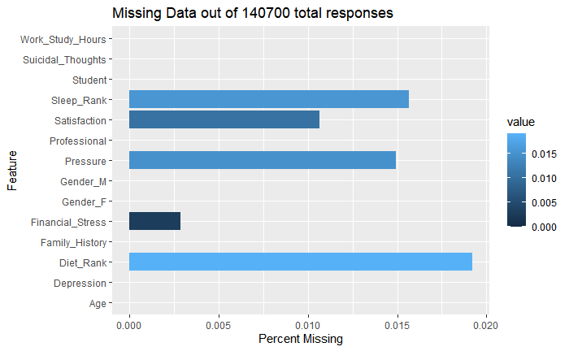

```r
data <- data %>% drop_na()
```

### Final Summary Tables

- feature counts with `1` and without depression `0`
  - percentages presented per row
- recall overall depression rate for survey population is **18%**

| **Characteristic** | **0** N = 115,077<sup>1</sup> | **1** N = 25,541<sup>1</sup> |
| --- | --- | --- |
| Gender_M | 63,139 (82%) | 14,285 (18%) |
| Gender_F | 51,938 (82%) | 11,256 (18%) |
| Professional | 103,523 (92%) | 9,222 (8.2%) |
| Student | 11,554 (41%) | 16,319 (59%) |
| Suicidal_Thoughts | 47,426 (68%) | 22,089 (32%) |
| Family_History | 56,762 (81%) | 13,147 (19%) |
| Age | 45 (37, 53) | 24 (20, 29) |
| Work_Study_Hours | 6.0 (2.0, 9.0) | 9.0 (6.0, 11.0) |

<sup>1</sup> n (%); Median (Q1, Q3)

| **Characteristic** | **0** N = 115,077<sup>1</sup> | **1** N = 25,541<sup>1</sup> |
| --- | --- | --- |
| Financial_Stress |  |  |
| 1 | 24,885 (92%) | 2,308 (8.5%) |
| 2 | 28,254 (90%) | 3,189 (10%) |
| 3 | 21,452 (83%) | 4,521 (17%) |
| 4 | 21,641 (78%) | 6,109 (22%) |
| 5 | 18,845 (67%) | 9,414 (33%) |
| Pressure |  |  |
| 1 | 24,938 (95%) | 1,415 (5.4%) |
| 2 | 26,186 (92%) | 2,353 (8.2%) |
| 3 | 23,668 (81%) | 5,678 (19%) |
| 4 | 21,377 (77%) | 6,283 (23%) |
| 5 | 18,908 (66%) | 9,812 (34%) |
| Satisfaction |  |  |
| 1 | 20,025 (72%) | 7,737 (28%) |
| 2 | 24,399 (80%) | 6,201 (20%) |
| 3 | 23,212 (84%) | 4,548 (16%) |
| 4 | 23,183 (85%) | 4,087 (15%) |
| 5 | 24,258 (89%) | 2,968 (11%) |
| Sleep_Rank |  |  |
| 1 | 29,702 (77%) | 9,094 (23%) |
| 2 | 26,822 (83%) | 5,319 (17%) |
| 3 | 30,372 (82%) | 6,588 (18%) |
| 4 | 28,181 (86%) | 4,540 (14%) |
| Diet_Rank |  |  |
| 1 | 34,169 (74%) | 12,041 (26%) |
| 2 | 41,458 (83%) | 8,223 (17%) |
| 3 | 39,450 (88%) | 5,277 (12%) |

<sup>1</sup> n (%)

## Modeling

- goal: build simple [logistic regression model](https://parsnip.tidymodels.org/articles/Examples.html?q=logistic_#logistic_reg-models) for proof of concept, then evaluate fit and results
  - not worried about tuning model parameters, cross-validation, etc . . .
  - [glmnet](https://parsnip.tidymodels.org/reference/details_logistic_reg_glmnet.html) engine with L2 regularization (Ridge), later compared to [glm](https://parsnip.tidymodels.org/reference/details_logistic_reg_glm.html) engine
- could retain `id` for more detailed results evaluation

*Code for loading and preparing data copied below for convenience*

```r
data <- read_csv("datasets/playground-series-s4e11_train.csv")

# rename features for plotting and indexing
names(data) <- gsub(" ", "_", names(data))
names(data) <- gsub("\\?", "", names(data))
names(data) <- gsub("/", "_", names(data))

# clean and encode sleep and diet into ranks
data <- data %>% mutate(Sleep_Rank = case_match(pull(data,Sleep_Duration),
  c("Less than 5 hours", "3-4 hours", "4-5 hours", "2-3 hours", "1-6 hours",
    "45", "1-2 hours", "1-3 hours", "3-6 hours") ~ 1,
  c("5-6 hours", "4-6 hours", "6-7 hours") ~ 2,
  c("7-8 hours", "6-8 hours", "8 hours") ~ 3,
  c("More than 8 hours", "10-11 hours", "8-9 hours", "9-11 hours") ~ 4
))

data <- data %>% mutate(Diet_Rank = case_match(pull(data,Dietary_Habits),
  c("Unhealthy") ~ 1,
  c("Moderate") ~ 2,
  c("Healthy") ~ 3,
))

# coalese student/professional specific features
data <- data %>% mutate(Pressure = coalesce(Academic_Pressure, Work_Pressure))
data <- data %>% mutate(Satisfaction = coalesce(Study_Satisfaction, Job_Satisfaction))

# encode binary features
data <- data %>% mutate(Gender_M = ifelse(Gender=="Male",1,0))
data <- data %>% mutate(Gender_F = ifelse(Gender=="Female",1,0))

data <- data %>% mutate(Professional = ifelse(Working_Professional_or_Student==
                                                "Working Professional",1,0))
data <- data %>% mutate(Student = ifelse(Working_Professional_or_Student==
                                                "Student",1,0))

data <- data %>% mutate(Suicidal_Thoughts = ifelse(
  Have_you_ever_had_suicidal_thoughts_=="Yes",1,0))

data <- data %>% mutate(Family_History = ifelse(
  Family_History_of_Mental_Illness=="Yes",1,0))

# drop columns, remove missing rows
keep_cols <- c(
  "Gender_M", "Gender_F", "Age", "Professional", "Student", "Suicidal_Thoughts",
  "Family_History", "Work_Study_Hours", "Financial_Stress", "Pressure",
  "Satisfaction", "Sleep_Rank", "Diet_Rank", "Depression"
)

data <- data[,keep_cols]
data <- data %>% drop_na()
```

*Convert target into a factor for modeling, confirm target stratification*

```r
data$Depression <- as.factor(data$Depression)

set.seed(42)

split <- initial_split(data, prop=0.8, strata=Depression)

train <- split %>% training()
test <- split %>% testing()

# head(train)
# head(test)

dplyr::count(train, Depression, sort = TRUE)
```

| Depression | n |
| --- | --- |
| 0 | 92061 |
| 1 | 20432 |

```r
dplyr::count(test, Depression, sort = TRUE)
```

| Depression | n |
| --- | --- |
| 0 | 23016 |
| 1 | 5109 |

```r
# GLMNet
model <- logistic_reg(mixture=double(1), penalty=double(1),
                      engine = "glmnet", mode="classification") %>%
  fit(Depression ~ ., data = train)

extract_spec_parsnip(model)
```

```
Logistic Regression Model Specification (classification)

Main Arguments:
  penalty = 0
  mixture = double(1)

Computational engine: glmnet

Model fit template:
glmnet::glmnet(x = missing_arg(), y = missing_arg(), weights = missing_arg(),
    alpha = double(1), family = "binomial")
```

```r
tidy(model)
```

| term | estimate | penalty |
| --- | --- | --- |
| (Intercept) | -0.53466950 | 0 |
| Gender_M | 0.01028416 | 0 |
| Gender_F | -0.01033482 | 0 |
| Age | -0.09262743 | 0 |
| Professional | -0.86943389 | 0 |
| Student | 0.86471487 | 0 |
| Suicidal_Thoughts | 1.54309181 | 0 |
| Family_History | 0.12928431 | 0 |
| Work_Study_Hours | 0.08502411 | 0 |
| Financial_Stress | 0.34794784 | 0 |

[output cut: 4 more lines]

### Feature Importance

- feature importance corresponds with data exploration findings above
  - `Suicidal_Thoughts` and being a `Student` vs. `Professional` most predictive
- positive or negative influence of features also matches above findings
  - *note opposing values for one hot encoded, binary features*

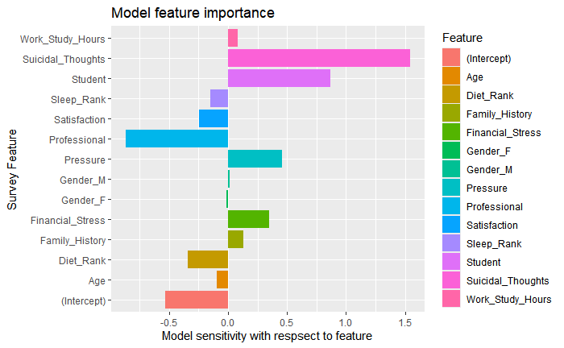

```r
# Class Predictions
pred_y <- predict(model, test,
                      type = "class")

# Class Probabilities
pred_proba <- predict(model, test,
                      type = "prob")

results <- test %>%
           select(Depression) %>%
           bind_cols(pred_y, pred_proba)

sample_n(results, 10)
```

| Depression | .pred_class | .pred_0 | .pred_1 |
| --- | --- | --- | --- |
| 0 | 0 | 0.9887023 | 0.011297712 |
| 0 | 0 | 0.9931295 | 0.006870549 |
| 0 | 0 | 0.8786061 | 0.121393893 |
| 0 | 0 | 0.9967938 | 0.003206162 |
| 0 | 0 | 0.9294923 | 0.070507677 |
| 0 | 0 | 0.8596584 | 0.140341596 |
| 1 | 1 | 0.4840859 | 0.515914084 |
| 0 | 0 | 0.9868025 | 0.013197518 |
| 0 | 0 | 0.9861728 | 0.013827200 |
| 0 | 1 | 0.4974302 | 0.502569826 |